# Quiz 6

Solutions

## Intro

This quiz is open everything, including notes, textbook, and whatever you might find on the internet. However, no interaction with other people is allowed. You have until noon EDT on October 14 to finish the quiz; there is no other time restriction. However, your file must be submitted on Canvas by the deadline; allow yourself time to download the file from RStudio Cloud to your computer and to submit it via Canvas.

For this quiz, we will use an artificial data set.

## First model

First, please fit a Bayesian linear model where `var1` is the outcome, with `var2` and `var3` as the predictor variables with no interaction.

Let’s take a look at the trace plots.

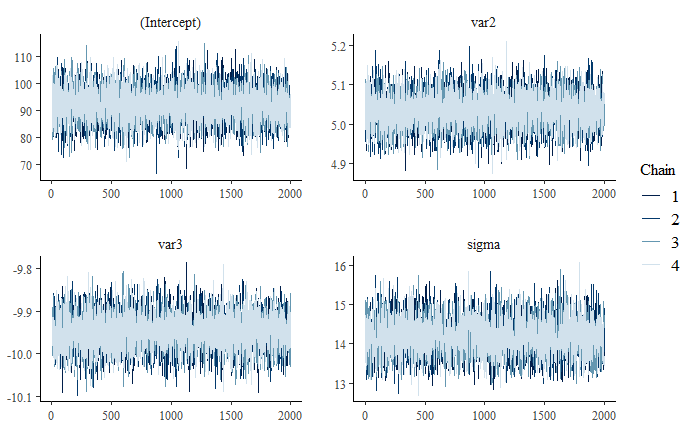

There are several ways to get 90% credible intervals. Use your favorite way to get 90% credible intervals of the parameters `(Intercept)`, `var2`, and `var3` in `model1`. (It doesn’t matter whether you get highest density intervals or equal tails intervals.) It is fine if the output produces additional information as long as the output explicitly shows a 90% credible intervals.

```
# Description of Posterior Distributions

Parameter   | Median |             90% CI | pd |          89% ROPE | % in ROPE |  Rhat |       ESS
--------------------------------------------------------------------------------------------------
(Intercept) | 92.290 | [ 81.950, 102.418] |  1 | [-17.374, 17.374] |         0 | 1.000 | 10552.744
var2        |  5.034 | [  4.964,   5.106] |  1 | [-17.374, 17.374] |       100 | 1.000 | 11506.504
var3        | -9.948 | [-10.013,  -9.877] |  1 | [-17.374, 17.374] |       100 | 1.000 |  9238.402

# Highest Density Interval

Parameter   |          90% HDI
------------------------------
(Intercept) | [ 81.95, 102.42]
var2        | [  4.96,   5.11]
var3        | [-10.01,  -9.88]

# Fixed effects

Parameter   | Median |           90% CI |   pd | % in ROPE |  Rhat |      ESS |                      Prior
----------------------------------------------------------------------------------------------------------
(Intercept) |  92.29 | [ 81.95, 102.42] | 100% |        0% | 1.000 | 10552.74 | Normal (-398.24 +- 434.36)
var2        |   5.03 | [  4.96,   5.11] | 100% |      100% | 1.000 | 11506.50 |     Normal (0.00 +- 29.51)
var3        |  -9.95 | [-10.01,  -9.88] | 100% |      100% | 1.000 |  9238.40 |     Normal (0.00 +- 28.12)
```

## Model 2

For the second model, please fit a model where: `var5` is the outcome, `var6` is the predictor variable, and there are separate intercepts (but not slopes) for each group as defined by `group_var`.

Please generate the posterior predictive check plot for `model2`.

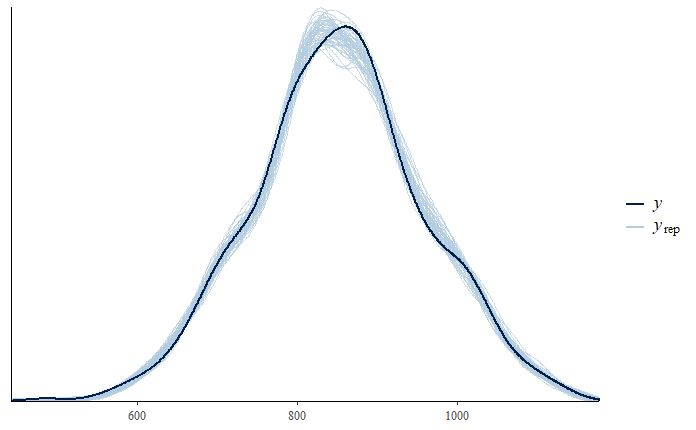

There are several ways to get the mean of the posterior for the regression coefficient of `var6`. Use your favorite way to do so. It is fine if the output produces additional information as long as the output explicitly shows the means.

```
# Description of Posterior Distributions

Parameter   |    Mean |            89% CI | pd |          89% ROPE | % in ROPE |  Rhat |       ESS
--------------------------------------------------------------------------------------------------
(Intercept) | 104.413 | [94.164, 114.514] |  1 | [-10.692, 10.692] |         0 | 1.000 |  6672.474
var6        |   7.460 | [ 7.382,   7.539] |  1 | [-10.692, 10.692] |       100 | 1.000 | 15360.594

# Fixed effects

Parameter   |   Mean |          89% CI |   pd | % in ROPE |  Rhat |      ESS |                     Prior
--------------------------------------------------------------------------------------------------------
(Intercept) | 104.41 | [94.16, 114.51] | 100% |        0% | 1.000 |  6672.47 | Normal (852.39 +- 267.29)
var6        |   7.46 | [ 7.38,   7.54] | 100% |      100% | 1.000 | 15360.59 |    Normal (0.00 +- 18.91)


Model Info:
 function:     stan_glmer
 family:       gaussian [identity]
 formula:      var5 ~ var6 + (1 | group_var)
 algorithm:    sampling
 sample:       16000 (posterior sample size)
 priors:       see help('prior_summary')
 observations: 500
 groups:       group_var (5)

Estimates:
                                           mean   sd    10%   50%   90%
(Intercept)                              104.4    6.4  96.2 104.4 112.4
var6                                       7.5    0.0   7.4   7.5   7.5
b[(Intercept) group_var:A]                 8.2    4.3   3.3   8.1  13.3
b[(Intercept) group_var:B]                 3.0    4.3  -1.9   3.0   8.1
b[(Intercept) group_var:C]                -3.9    4.3  -8.9  -3.8   1.1
b[(Intercept) group_var:D]                 0.5    4.3  -4.4   0.5   5.5
b[(Intercept) group_var:E]                -7.8    4.3 -12.9  -7.7  -2.9
sigma                                     15.1    0.5  14.5  15.1  15.7
Sigma[group_var:(Intercept),(Intercept)]  85.5  109.3  21.7  54.8 170.9

Fit Diagnostics:
           mean   sd    10%   50%   90%
mean_PPD 852.4    1.0 851.2 852.4 853.6

The mean_ppd is the sample average posterior predictive distribution of the outcome variable (for details see help('summary.stanreg')).

MCMC diagnostics
                                         mcse Rhat n_eff
(Intercept)                              0.1  1.0   6672
var6                                     0.0  1.0  15361
b[(Intercept) group_var:A]               0.1  1.0   3852
b[(Intercept) group_var:B]               0.1  1.0   3735
b[(Intercept) group_var:C]               0.1  1.0   3702
b[(Intercept) group_var:D]               0.1  1.0   3644
b[(Intercept) group_var:E]               0.1  1.0   3719
sigma                                    0.0  1.0  12852
Sigma[group_var:(Intercept),(Intercept)] 1.5  1.0   5431
mean_PPD                                 0.0  1.0  16336
log-posterior                            0.0  1.0   4311

For each parameter, mcse is Monte Carlo standard error, n_eff is a crude measure of effective sample size, and Rhat is the potential scale reduction factor on split chains (at convergence Rhat=1).
```

A quick look at the densities of three of the parameters (nothing for you to do here).

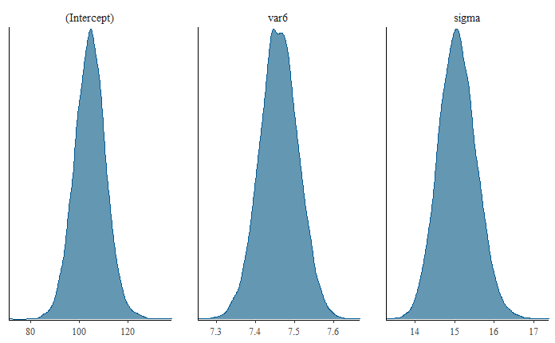

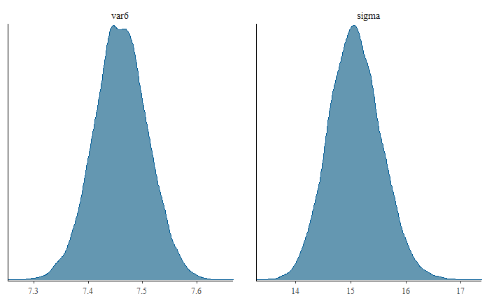

What is the probability that the `var6` coefficient is greater than 7.5?

```
[1] 0.20825
```